# SmithKaartOefening3 slides

Smith Kaart

Oefening 3

Jan Genoe

December 2025

###### Opgave

Wat is een Smith kaart? Welke waarde wordt er op deze kaart uitgezet? Hoe gebruik je een Smith kaart om een antenne van 30 Ohm aan te passen aan een printbaan van 60 Ohm voor een frequentie van 1.2 GHz ($\lambda$= 12.5 cm)?

###### Smith kaart van de eerste oplossing: C in serie

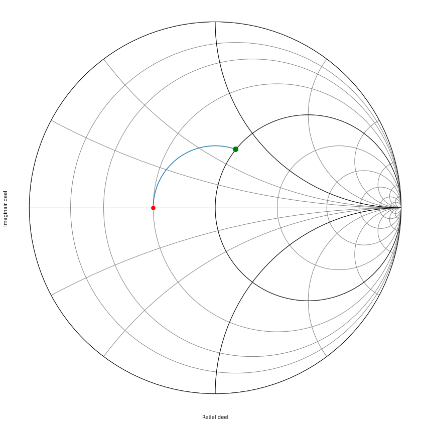

###### Circuit van de eerste oplossing

[figure not shown]

###### Smith kaart van de tweede oplossing: L in serie

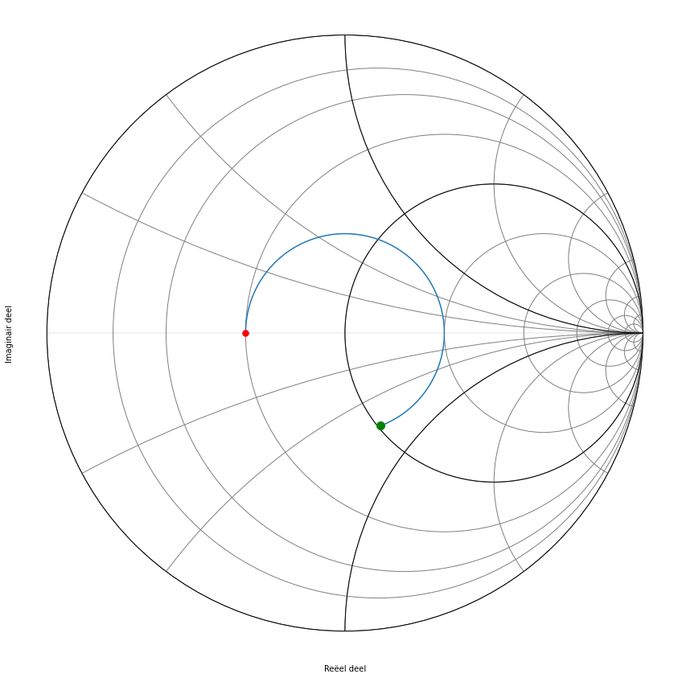

###### Circuit van de tweede oplossing

[figure not shown]

###### Smith kaart van de derde oplossing: C in parallel

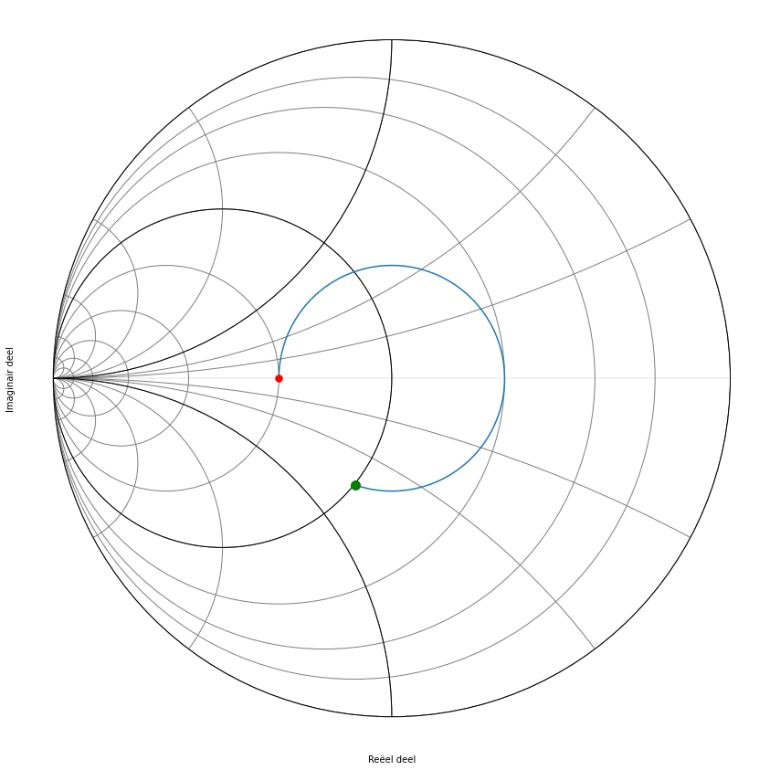

###### Smith kaart van de derde oplossing als admitantie

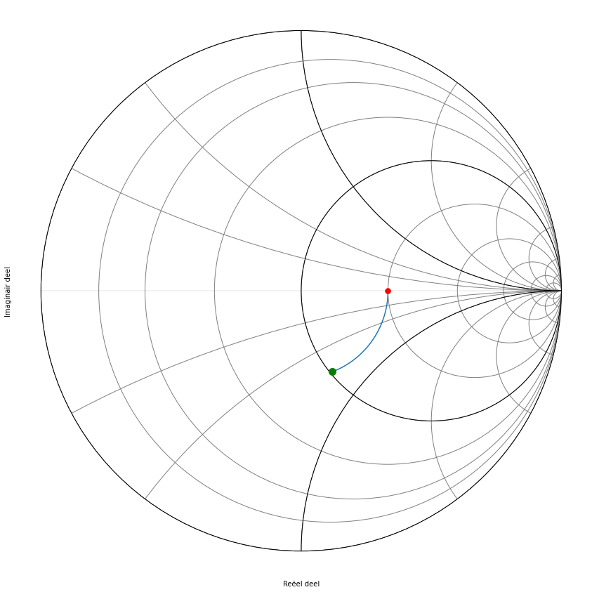

###### Circuit van de derde oplossing

[figure not shown]

###### Smith kaart van de vierde oplossing: L in parallel

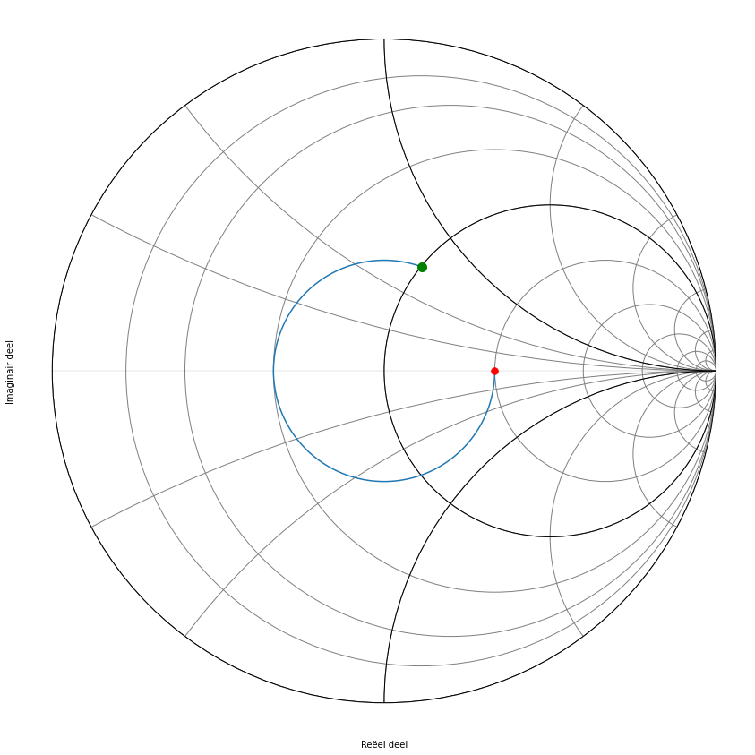

###### Circuit van de vierde oplossing

[figure not shown]

###### Smith kaart van de vijfde oplossing: C => open transmissielijn

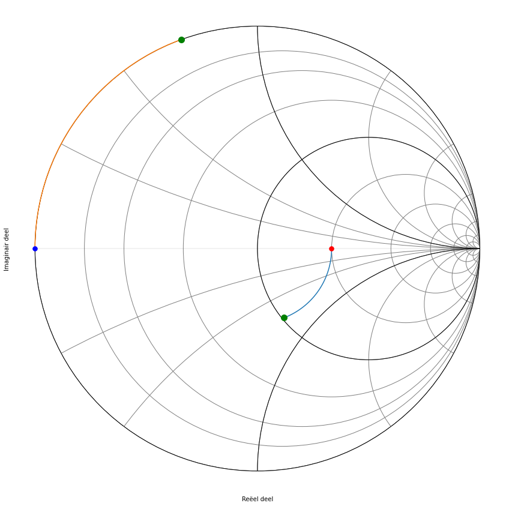

###### Circuit van de vijfde oplossing

[figure not shown]

###### Smith kaart van de zesde oplossing: C => kortgesloten transmissielijn

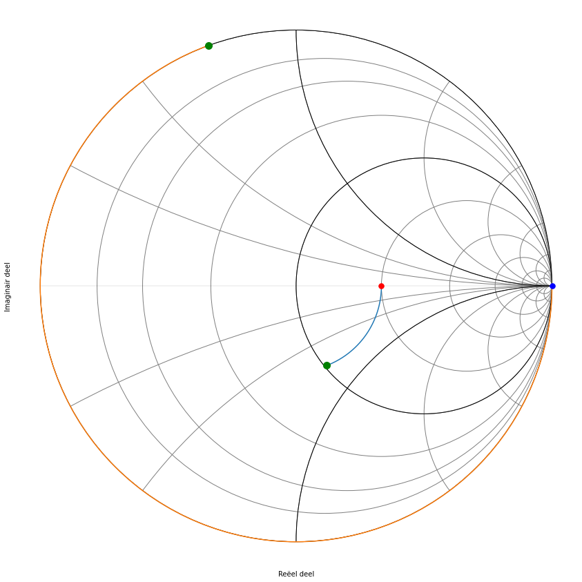

Overzicht van de bekomen admittantie als functie van de hoek op de Smith kaart. De laatste kolom geeft de nodige lengte van de coax

```
hoek    admitantie (Siemens)     lengte coax (cm)
 250       Y= +11.67j mS     lengte=4.34 cm
 251       Y= +11.89j mS     lengte=4.36 cm
 252       Y= +12.11j mS     lengte=4.38 cm
 253       Y= +12.33j mS     lengte=4.39 cm
 254       Y= +12.56j mS     lengte=4.41 cm
```

Het schema dat we nodig hebben om deze zesde oplossing te realiseren wordt dus:

###### Circuit van de zesde oplossing

[figure not shown]

###### Smith kaart van de zevende oplossing: L => open transmissielijn

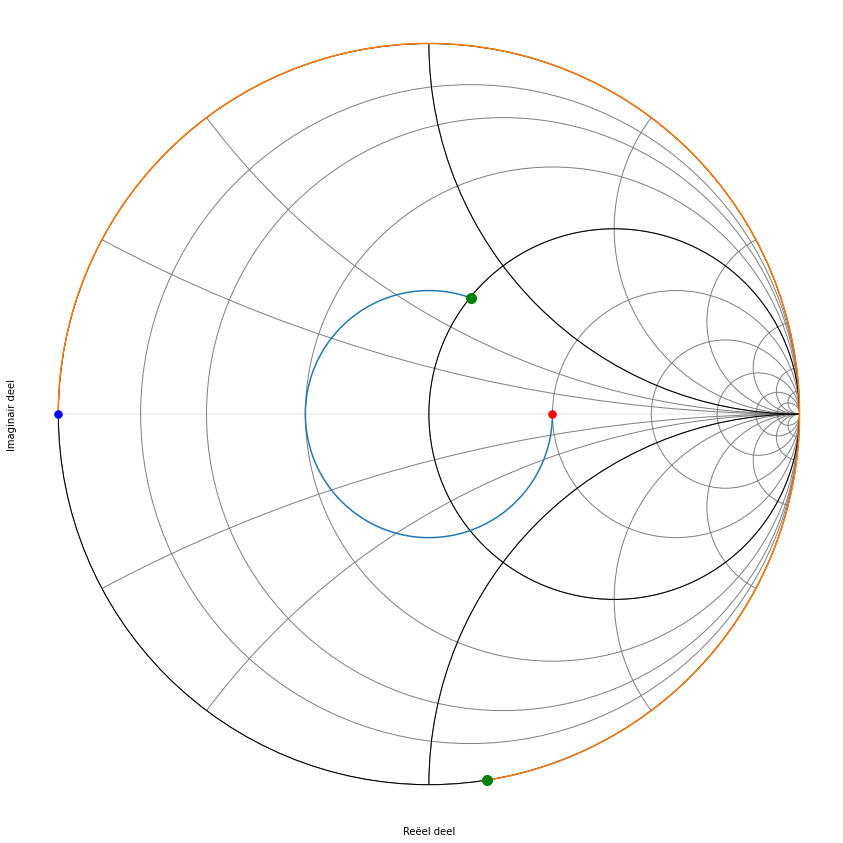

```
hoek    admitantie (Siemens)     lengte coax (cm)
 285    Y= 15.78+11.44j mS     lengte=4.95 cm
 286    Y= 15.98+11.52j mS     lengte=4.97 cm
 287    Y= 16.17+11.60j mS     lengte=4.98 cm
 288    Y= 16.37+11.68j mS     lengte=5.00 cm
 289    Y= 16.57+11.75j mS     lengte=5.02 cm
 290    Y= 16.78+11.82j mS     lengte=5.03 cm
```

Overzicht van de bekomen admittantie als functie van de hoek op de Smith kaart. De laatste kolom geeft de nodige lengte van de coax

```
hoek    admitantie (Siemens)     lengte coax (cm)
 285       Y= -12.79j mS     lengte=4.95 cm
 286       Y= -12.56j mS     lengte=4.97 cm
 287       Y= -12.33j mS     lengte=4.98 cm
 288       Y= -12.11j mS     lengte=5.00 cm
 289       Y= -11.89j mS     lengte=5.02 cm
 290       Y= -11.67j mS     lengte=5.03 cm
```

Overzicht van de bekomen admittantie als functie van de hoek op de Smith kaart. De laatste kolom geeft de nodige lengte van de coax

Het schema dat we nodig hebben om deze zevende oplossing te realiseren wordt dus:

###### Circuit van de zevende oplossing

[figure not shown]

###### Smith kaart van de achtste oplossing: L => kortgesloten transmissielijn

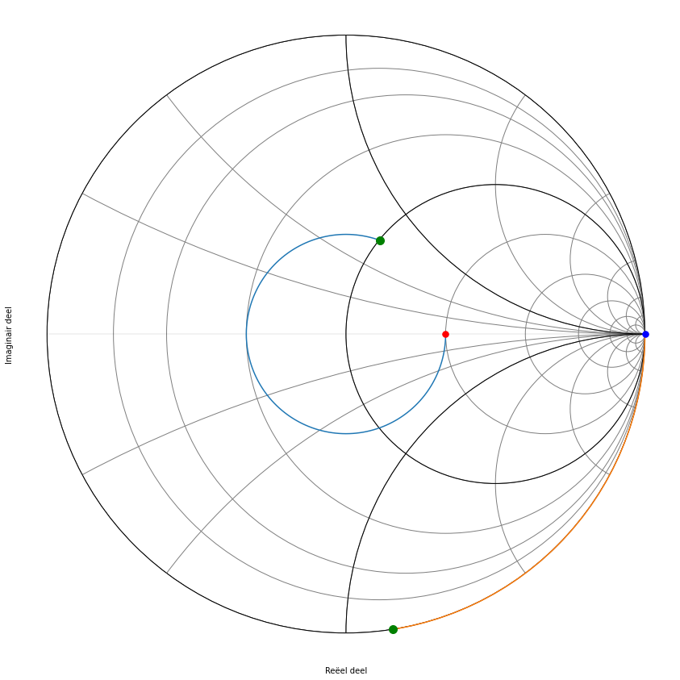

```
hoek    admitantie (Siemens)     lengte coax (cm)
 285    Y= 15.78+11.44j mS     lengte=4.95 cm
 286    Y= 15.98+11.52j mS     lengte=4.97 cm
 287    Y= 16.17+11.60j mS     lengte=4.98 cm
 288    Y= 16.37+11.68j mS     lengte=5.00 cm
 289    Y= 16.57+11.75j mS     lengte=5.02 cm
 290    Y= 16.78+11.82j mS     lengte=5.03 cm
```

Overzicht van de bekomen admittantie als functie van de hoek op de Smith kaart. De laatste kolom geeft de nodige lengte van de coax

```
hoek    admitantie (Siemens)     lengte coax (cm)
 105       Y= -12.79j mS     lengte=1.82 cm
 106       Y= -12.56j mS     lengte=1.84 cm
 107       Y= -12.33j mS     lengte=1.86 cm
 108       Y= -12.11j mS     lengte=1.88 cm
 109       Y= -11.89j mS     lengte=1.89 cm
 110       Y= -11.67j mS     lengte=1.91 cm
```

Overzicht van de bekomen admittantie als functie van de hoek op de Smith kaart. De laatste kolom geeft de nodige lengte van de coax

Het stukje kortgesloten coax dat we moeten voorzien ter vervanging van het spoel is dus: 1.9 cm

###### Circuit van de achtste oplossing

[figure not shown]

I would rather have questions that can't be answered  
than answers that can't be questioned.

Richard Feynman